# Predicting Latents in the RAISE Dataset

Alexander Rix

November 16, 2017

```r
suppressPackageStartupMessages(
library(tidyverse)
)
setwd("~/work/RAISE")
```

```r
RAISE <- suppressMessages(
read_csv("./alldata.csv", progress = F)
)
# turn NaNs into NAs
library("parallel")
RAISE <-  as.data.frame(
  mclapply(RAISE, function(x) {ifelse(is.nan(x), NA, x)}
  )
)
```

We are interested in determining the following latents: L4, L7, L9, and L10

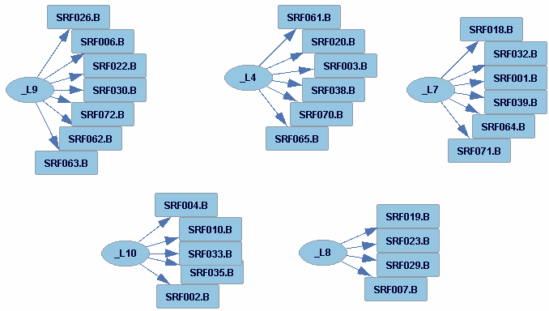

There are two problems at hand

1. There are missing values in this dataset that need to be dealt with
2. Then the latents need to be predicted by the `lavaan` package in `R`. We have a couple options here and potentially some problems arise.

## Looking at the missing values

I think the first thing to do is to the missing data pattern in the variables of interest.

```
 Variables sorted by number of missings:
 Variable Count
 SRF064.B    17
 SRF061.B    17
 SRF062.B    16
 SRF063.B    16
 SRF072.B    11
 SRF003.B     7
 SRF065.B     7
 SRF004.B     6
 SRF001.B     6
 SRF071.B     6
 SRF070.B     6
 SRF006.B     5
 SRF002.B     5
 SRF022.B     4
 SRF039.B     4
 SRF020.B     4
 SRF038.B     4
 SRF026.B     3
 SRF010.B     3
 SRF035.B     3
 SRF018.B     3
 SRF030.B     2
 SRF033.B     2
 SRF032.B     2
```

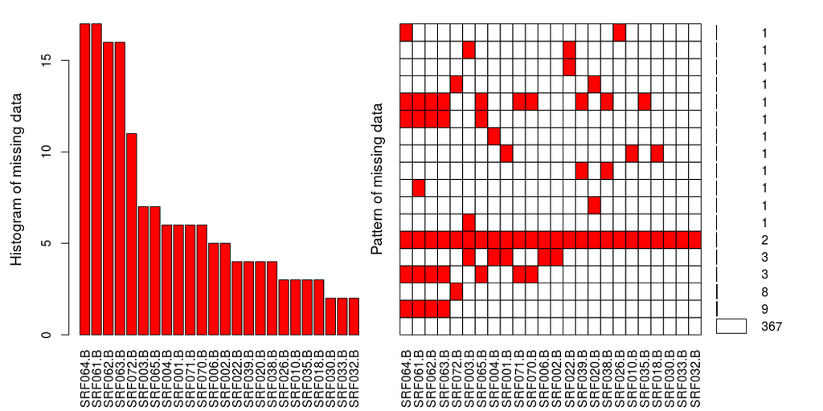

```r
VARS_WE_CARE_ABOUT <- select(RAISE, c(SRF026.B, SRF006.B, SRF022.B, SRF030.B, SRF072.B, SRF062.B, SRF063.B, SRF004.B, SRF010.B, SRF033.B, SRF035.B, SRF002.B , SRF018.B, SRF032.B, SRF001.B, SRF039.B, SRF064.B, SRF071.B, SRF061.B, SRF020.B, SRF003.B, SRF038.B, SRF070.B, SRF065.B))
library(VIM)
aggr(VARS_WE_CARE_ABOUT, col=c('white','red'), numbers = T, sortVars = T, labels = names(VARS_WE_CARE_ABOUT), prop = F,
    cex.axis = 1, gap = 2, ylab = c("Histogram of missing data","Pattern of missing data"))
```

We can glean a couple things from this data.

1. 367 of the 404 observations are complete with respect to subset of variables are working with. So, about 90% of our data is complete.
2. There are 2 observations that are completely missing. I am going to drop these observations.

```r
# hack to drop those missing obs from the dataset(s)
RAISE <- RAISE %>% drop_na(SRF032.B)
VARS_WE_CARE_ABOUT <- VARS_WE_CARE_ABOUT %>% drop_na(SRF032.B)
```

Now, we have two options to deal with the rest of the missing data. Omitting the rows with missing data seems unwise to me, since we don’t have that many samples to work with. That leaves us the option to impute, or perform CFA only on complete rows. The missing data pattern implies the data is actually almost complete…

```r
1 - sum(is.na(VARS_WE_CARE_ABOUT))/(402*24)
```

```
[1] 0.988495
```

Relatively few entries are missing. So, I think imputing will perform well here.

```r
# lavaan would like these to be kept as ordered variables instead of continuous
VARS_WE_CARE_ABOUT <- as.data.frame(
  mclapply(VARS_WE_CARE_ABOUT, function(x) {as.ordered(x)}
  )
)
# This variable is an integer from 1-100 (really its 1-59).
# It is on the different scale then the rest, so I'm going to normalize it after I impute it
VARS_WE_CARE_ABOUT$SRF072.B <- as.double(VARS_WE_CARE_ABOUT$SRF072.B)
library(mice)
RAISE_imp <- mice(VARS_WE_CARE_ABOUT, m = 5, printFlag = F )
```

Now, we need to specify the latent variable model given by Erich’s graph. In `lavaan`, the syntax is

```r
lv.model <- 'L9 =~ SRF026.B + SRF006.B + SRF022.B + SRF030.B + SRF072.B + SRF062.B + SRF063.B
             L10 =~ SRF004.B + SRF010.B + SRF033.B + SRF035.B + SRF002.B
             L7 =~ SRF018.B + SRF032.B + SRF001.B + SRF039.B + SRF064.B + SRF071.B
             L4 =~ SRF061.B + SRF020.B + SRF003.B + SRF038.B + SRF070.B + SRF065.B
            '
```

Now, we are ready to fit the models

```r
library(lavaan)
fits <- c(
cfa(lv.model, data = mice.imp[[1]]),
cfa(lv.model, data = mice.imp[[2]]),
cfa(lv.model, data = mice.imp[[4]]),
cfa(lv.model, data = mice.imp[[3]]),
cfa(lv.model, data = mice.imp[[5]])
)
```

[output not shown]

As we can see, there is an error when `lavaan` fits a CFA on all these imputed datasets. (I’m pretty sure the zero.table.cells is unimportant). The covariance / correlation matrices are not positive-definite. Now, `lavaan` refuses to make predictions when this happens, so strictly speaking, we need to look at what `lavaan` thinks the covariance/correlation matrices are.

```r
inspect(fits[[1]], "cov.lv")
```

```
    L9    L10   L7    L4
L9  0.418
L10 0.207 0.116
L7  0.275 0.196 0.192
L4  0.167 0.113 0.171 0.066
```

```r
# not good
eigen(inspect(fits[[1]], "cov.lv"))$values
```

```
[1]  0.82147257  0.05673158 -0.02301055 -0.06313379
```

```r
# notice how estimated correlation matrix has values > 1
inspect(fits[[1]], "cor.lv")
```

```
    L9    L10   L7    L4
L9  1.000
L10 0.940 1.000
L7  0.970 1.314 1.000
L4  1.004 1.287 1.517 1.000
```

Assuming all the variable are actually continuous instead of ordered will allow `lavaan` to make predictions (Also: there is a paper I need to read that seems to suggest I *can* do this), but the problem of non positive definiteness remains, so I do not trust the predictions.

I don’t know a whole lot about CFAs, or SEM, but from what I’m reading on the internet, it seems like the model isn’t correctly specified. I don’t know if that means that we need to specify the covariances between latents, or if there’s something off elsewhere.

## Update 11/16

```r
fits <- c(
sem(lv.model, data = mice.imp[[1]]),
sem(lv.model, data = mice.imp[[2]]),
sem(lv.model, data = mice.imp[[4]]),
sem(lv.model, data = mice.imp[[3]]),
sem(lv.model, data = mice.imp[[5]])
)
```

[output not shown]

No dice!

### fitting each latent model separately.

```r
models <- c(
'L9 =~ SRF026.B + SRF006.B + SRF022.B + SRF030.B + SRF072.B + SRF062.B + SRF063.B',
'L10 =~ SRF004.B + SRF010.B + SRF033.B + SRF035.B + SRF002.B',
'L7 =~ SRF018.B + SRF032.B + SRF001.B + SRF039.B + SRF064.B + SRF071.B',
'L4 =~ SRF061.B + SRF020.B + SRF003.B + SRF038.B + SRF070.B + SRF065.B'
)
fits <- c(
cfa(models[1], data = mice.imp[[1]]),
cfa(models[1], data = mice.imp[[2]]),
cfa(models[1], data = mice.imp[[4]]),
cfa(models[1], data = mice.imp[[3]]),
cfa(models[1], data = mice.imp[[5]])
)
```

```
lavaan WARNING: 12 bivariate tables have empty cells; to see them, use:
                  lavInspect(fit, "zero.cell.tables")lavaan WARNING: 12 bivariate tables have empty cells; to see them, use:
                  lavInspect(fit, "zero.cell.tables")lavaan WARNING: 12 bivariate tables have empty cells; to see them, use:
                  lavInspect(fit, "zero.cell.tables")lavaan WARNING: 12 bivariate tables have empty cells; to see them, use:
                  lavInspect(fit, "zero.cell.tables")lavaan WARNING: 12 bivariate tables have empty cells; to see them, use:
                  lavInspect(fit, "zero.cell.tables")
```

```r
latent_estimate <- c()
for ( fit in fits) {
latent_estimate <- cbind(latent_estimate, predict(fit))
}
```

So, we get no errors now. The question of how to pool the results remains. I think we should take a look the covariance matrix of imputed models.

```r
colnames(latent_estimate) = paste(colnames(latent_estimate), "_" , seq(1:5) , sep = "")
cov(latent_estimate)
```

```
          L9_1      L9_2      L9_3      L9_4      L9_5
L9_1 0.3291966 0.3299515 0.3290933 0.3318401 0.3318088
L9_2 0.3299515 0.3311205 0.3301241 0.3327539 0.3330250
L9_3 0.3290933 0.3301241 0.3297349 0.3318729 0.3322068
L9_4 0.3318401 0.3327539 0.3318729 0.3353241 0.3350712
L9_5 0.3318088 0.3330250 0.3322068 0.3350712 0.3355008
```

As we can see, the predictions themselves are so close that we can just average them (or we could pick one). The most correct would be to pool the covariance matrices generated by `lavaan`, but I do not think that is necessary given how close everything is.

## Some code and some comments

This code fits 4 1-factor models (is this the correct way to say it?) and appends them to RAISE. It prints out the fit statistics ([an explanation of them can be found here](http://davidakenny.net/cm/fit.htm)) on each model and the above covariance matrix for latent. **BE SURE TO READ TILL THE END**

```r
models <- c(
'L9 =~ SRF026.B + SRF006.B + SRF022.B + SRF030.B + SRF072.B + SRF062.B + SRF063.B',
'L10 =~ SRF004.B + SRF010.B + SRF033.B + SRF035.B + SRF002.B',
'L7 =~ SRF018.B + SRF032.B + SRF001.B + SRF039.B + SRF064.B + SRF071.B',
'L4 =~ SRF061.B + SRF020.B + SRF003.B + SRF038.B + SRF070.B + SRF065.B'
)
for (model in models) {
  # perform cfa on each imputed dataset for the given models
  fits <- c(
  cfa(model, data = mice.imp[[1]]),
  cfa(model, data = mice.imp[[2]]),
  cfa(model, data = mice.imp[[4]]),
  cfa(model, data = mice.imp[[3]]),
  cfa(model, data = mice.imp[[5]])
  )
  # predict value of latents from each fit
  latent_estimates <- c()
  for ( fit in fits) {
  latent_estimates <- cbind(latent_estimates, predict(fit))
  }
  # hack to get name of latent
var_name <- colnames(latent_estimates)[1]
colnames(latent_estimates) = paste(colnames(latent_estimates), "_" , seq(1:5) , sep = "")
summary(fit, fit.measures = T, estimates = F)
print(cov(latent_estimates))
estimate <- rowMeans(latent_estimates)
RAISE[var_name] <- estimate
}
```

[output not shown]

```
lavaan (0.5-23.1097) converged normally after  15 iterations

  Number of observations                           402

  Estimator                                       DWLS      Robust
  Minimum Function Test Statistic               17.489      30.428
  Degrees of freedom                                14          14
  P-value (Chi-square)                           0.231       0.007
  Scaling correction factor                                  0.595
  Shift parameter                                            1.010
    for simple second-order correction (Mplus variant)

Model test baseline model:

  Minimum Function Test Statistic             1099.645     771.011
  Degrees of freedom                                21          21
  P-value                                        0.000       0.000

User model versus baseline model:

  Comparative Fit Index (CFI)                    0.997       0.978
  Tucker-Lewis Index (TLI)                       0.995       0.967

  Robust Comparative Fit Index (CFI)                            NA
  Robust Tucker-Lewis Index (TLI)                               NA

Root Mean Square Error of Approximation:

  RMSEA                                          0.025       0.054
  90 Percent Confidence Interval          0.000  0.057       0.027  0.080
  P-value RMSEA <= 0.05                          0.886       0.363

  Robust RMSEA                                                  NA
  90 Percent Confidence Interval                                NA     NA

Standardized Root Mean Square Residual:

  SRMR                                           0.036       0.036

Weighted Root Mean Square Residual:

  WRMR                                           0.549       0.549
          L9_1      L9_2      L9_3      L9_4      L9_5
L9_1 0.3291966 0.3299515 0.3290933 0.3318401 0.3318088
L9_2 0.3299515 0.3311205 0.3301241 0.3327539 0.3330250
L9_3 0.3290933 0.3301241 0.3297349 0.3318729 0.3322068
L9_4 0.3318401 0.3327539 0.3318729 0.3353241 0.3350712
L9_5 0.3318088 0.3330250 0.3322068 0.3350712 0.3355008
```

[output not shown]

```
lavaan (0.5-23.1097) converged normally after  20 iterations

  Number of observations                           402

  Estimator                                       DWLS      Robust
  Minimum Function Test Statistic                2.751       4.551
  Degrees of freedom                                 5           5
  P-value (Chi-square)                           0.738       0.473
  Scaling correction factor                                  0.626
  Shift parameter                                            0.158
    for simple second-order correction (Mplus variant)

Model test baseline model:

  Minimum Function Test Statistic              436.594     352.352
  Degrees of freedom                                10          10
  P-value                                        0.000       0.000

User model versus baseline model:

  Comparative Fit Index (CFI)                    1.000       1.000
  Tucker-Lewis Index (TLI)                       1.011       1.003

  Robust Comparative Fit Index (CFI)                            NA
  Robust Tucker-Lewis Index (TLI)                               NA

Root Mean Square Error of Approximation:

  RMSEA                                          0.000       0.000
  90 Percent Confidence Interval          0.000  0.050       0.000  0.066
  P-value RMSEA <= 0.05                          0.951       0.853

  Robust RMSEA                                                  NA
  90 Percent Confidence Interval                             0.000     NA

Standardized Root Mean Square Residual:

  SRMR                                           0.019       0.019

Weighted Root Mean Square Residual:

  WRMR                                           0.273       0.273
           L10_1     L10_2     L10_3      L10_4     L10_5
L10_1 0.09836894 0.1007273 0.1022565 0.09887086 0.1000225
L10_2 0.10072733 0.1031902 0.1047538 0.10124210 0.1024152
L10_3 0.10225649 0.1047538 0.1065735 0.10275587 0.1041596
L10_4 0.09887086 0.1012421 0.1027559 0.09937813 0.1005128
L10_5 0.10002246 0.1024152 0.1041596 0.10051279 0.1019169
```

[output not shown]

```
lavaan (0.5-23.1097) converged normally after  23 iterations

  Number of observations                           402

  Estimator                                       DWLS      Robust
  Minimum Function Test Statistic                5.393       6.954
  Degrees of freedom                                 9           9
  P-value (Chi-square)                           0.799       0.642
  Scaling correction factor                                  0.795
  Shift parameter                                            0.175
    for simple second-order correction (Mplus variant)

Model test baseline model:

  Minimum Function Test Statistic              243.032     223.470
  Degrees of freedom                                15          15
  P-value                                        0.000       0.000

User model versus baseline model:

  Comparative Fit Index (CFI)                    1.000       1.000
  Tucker-Lewis Index (TLI)                       1.026       1.016

  Robust Comparative Fit Index (CFI)                            NA
  Robust Tucker-Lewis Index (TLI)                               NA

Root Mean Square Error of Approximation:

  RMSEA                                          0.000       0.000
  90 Percent Confidence Interval          0.000  0.036       0.000  0.046
  P-value RMSEA <= 0.05                          0.987       0.964

  Robust RMSEA                                                  NA
  90 Percent Confidence Interval                             0.000     NA

Standardized Root Mean Square Residual:

  SRMR                                           0.024       0.024

Weighted Root Mean Square Residual:

  WRMR                                           0.332       0.332
           L7_1       L7_2       L7_3       L7_4       L7_5
L7_1 0.09893025 0.09725889 0.09812777 0.09710732 0.09770477
L7_2 0.09725889 0.09573890 0.09657709 0.09561654 0.09615237
L7_3 0.09812777 0.09657709 0.09750481 0.09649651 0.09697747
L7_4 0.09710732 0.09561654 0.09649651 0.09577293 0.09613738
L7_5 0.09770477 0.09615237 0.09697747 0.09613738 0.09678747
```

[output not shown]

```
lavaan (0.5-23.1097) converged normally after  29 iterations

  Number of observations                           402

  Estimator                                       DWLS      Robust
  Minimum Function Test Statistic               18.600      25.043
  Degrees of freedom                                 9           9
  P-value (Chi-square)                           0.029       0.003
  Scaling correction factor                                  0.757
  Shift parameter                                            0.479
    for simple second-order correction (Mplus variant)

Model test baseline model:

  Minimum Function Test Statistic              325.793     287.513
  Degrees of freedom                                15          15
  P-value                                        0.000       0.000

User model versus baseline model:

  Comparative Fit Index (CFI)                    0.969       0.941
  Tucker-Lewis Index (TLI)                       0.949       0.902

  Robust Comparative Fit Index (CFI)                            NA
  Robust Tucker-Lewis Index (TLI)                               NA

Root Mean Square Error of Approximation:

  RMSEA                                          0.052       0.067
  90 Percent Confidence Interval          0.016  0.085       0.036  0.098
  P-value RMSEA <= 0.05                          0.421       0.164

  Robust RMSEA                                                  NA
  90 Percent Confidence Interval                                NA     NA

Standardized Root Mean Square Residual:

  SRMR                                           0.046       0.046

Weighted Root Mean Square Residual:

  WRMR                                           0.610       0.610
           L4_1       L4_2       L4_3       L4_4       L4_5
L4_1 0.04886764 0.04707872 0.04622243 0.04695748 0.04630870
L4_2 0.04707872 0.04550569 0.04466479 0.04529595 0.04477599
L4_3 0.04622243 0.04466479 0.04384866 0.04447879 0.04395365
L4_4 0.04695748 0.04529595 0.04447879 0.04533984 0.04460622
L4_5 0.04630870 0.04477599 0.04395365 0.04460622 0.04411421
```

I would like to reiterate fitting 4 1-factor models seems to imply that the covariance matrix between the latents is 0 when off the diagonal. My reasoning is based off the `lavaan` [tutorial](http://lavaan.ugent.be/tutorial/cfa.html) where the fit this model

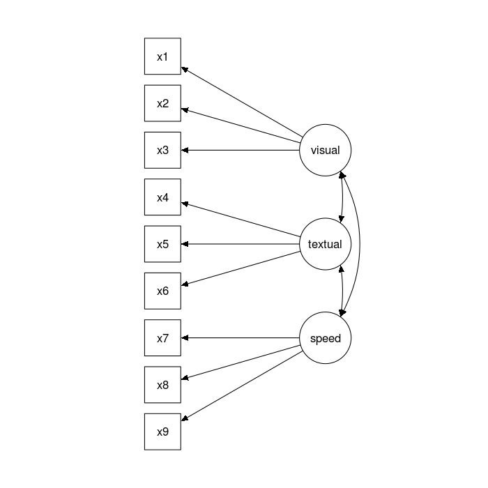

with this syntax

```
 visual =~ x1 + x2 + x3
textual =~ x4 + x5 + x6
  speed =~ x7 + x8 + x9
```

Now, the correlation matrix between the predicted latents is

```r
latents <- select(RAISE, c(L9, L10, L4, L7))
cor(latents)
```

```
           L9       L10        L4        L7
L9  1.0000000 0.6421499 0.6887161 0.5623873
L10 0.6421499 1.0000000 0.7171389 0.7119606
L4  0.6887161 0.7171389 1.0000000 0.7032765
L7  0.5623873 0.7119606 0.7032765 1.0000000
```

I think talking to someone who is familiar with CFA would be a good idea. They could probably tell us if doing this thing is okay.